# EC0866: Wildfire-specific fine particulate matter and pre in the U.S. ECHO-wide cohort

Multivariate Analyses - OUTCOME: PET/Eclampsia

Daniel Beene

March 31, 2026

# 1 Models

Outcome: compost variable of preeclampsia and eclampsia. Models performed on full dataset; n = 21034

## 1.1 Unadjusted

Unadjusted GLMM Results: All Exposure Metrics

| Exposure | OR | 95% CI Low | 95% CI High | P-value |
| --- | --- | --- | --- | --- |
| preg_smoke_days | 1.001 | 0.999 | 1.004 | 0.3463 |
| T1_smoke_days | 1.002 | 0.998 | 1.006 | 0.3607 |
| T2_smoke_days | 1.004 | 1.000 | 1.007 | 0.0324 |
| T3_smoke_days | 1.004 | 0.998 | 1.010 | 0.1843 |
| preg_smoke_days_over5 | 0.999 | 0.991 | 1.007 | 0.8023 |
| T1_smoke_days_over5 | 1.000 | 0.987 | 1.013 | 0.9969 |
| T2_smoke_days_over5 | 1.006 | 0.995 | 1.017 | 0.3204 |
| T3_smoke_days_over5 | 1.011 | 0.994 | 1.029 | 0.2008 |
| preg_smoke_days_over10 | 0.995 | 0.979 | 1.012 | 0.5561 |
| T1_smoke_days_over10 | 0.998 | 0.971 | 1.025 | 0.8634 |
| T2_smoke_days_over10 | 1.002 | 0.978 | 1.027 | 0.8577 |
| T3_smoke_days_over10 | 1.020 | 0.985 | 1.056 | 0.2634 |
| preg_smokePM_mean | 1.093 | 0.971 | 1.230 | 0.1407 |
| T1_smokePM_mean | 1.004 | 0.939 | 1.074 | 0.9091 |
| T2_smokePM_mean | 1.047 | 0.975 | 1.124 | 0.2046 |
| T3_smokePM_mean | 1.036 | 0.985 | 1.090 | 0.1712 |

## 1.2 Primary Adjusted

From AP: “Primary models will be adjusted for variables widely available across cohorts including maternal age, education, parity, race/ethnicity.”

Primary Adjusted Model: preg_smoke_days

| Term | OR | 95% CI Low | 95% CI High | P-value |
| --- | --- | --- | --- | --- |
| Intercept | 0.110 | 0.075 | 0.161 | 0.0000 |
| preg_smoke_days (exposure) | 1.001 | 0.999 | 1.004 | 0.3118 |
| Maternal age (term 1) | 0.918 | 0.609 | 1.385 | 0.6849 |
| Maternal age (term 2) | 1.176 | 1.087 | 1.271 | 0.0000 |
| Education: High school | 0.733 | 0.563 | 0.954 | 0.0209 |
| Education: Some college | 0.805 | 0.629 | 1.030 | 0.0850 |
| Education: Bachelor’s degree | 0.637 | 0.490 | 0.828 | 0.0007 |
| Education: Postgraduate degree | 0.535 | 0.406 | 0.706 | 0.0000 |
| Parity (1) | 0.605 | 0.528 | 0.693 | 0.0000 |
| Parity (2) | 0.551 | 0.448 | 0.678 | 0.0000 |
| Parity (3+) | 0.553 | 0.430 | 0.713 | 0.0000 |
| Race: Black | 1.342 | 1.078 | 1.670 | 0.0085 |
| Race: Asian | 0.749 | 0.544 | 1.030 | 0.0753 |
| Race: AI/AN | 0.713 | 0.419 | 1.212 | 0.2110 |
| Race: Other/multiple | 0.686 | 0.459 | 1.025 | 0.0658 |
| Ethnicity: Hispanic (any race) | 1.037 | 0.860 | 1.250 | 0.7068 |
| Infant sex (male) | 1.047 | 0.934 | 1.173 | 0.4325 |

Primary Adjusted Model: T1_smoke_days

| Term | OR | 95% CI Low | 95% CI High | P-value |
| --- | --- | --- | --- | --- |
| Intercept | 0.112 | 0.077 | 0.163 | 0.0000 |
| T1_smoke_days (exposure) | 1.002 | 0.998 | 1.007 | 0.2873 |
| Maternal age (term 1) | 0.916 | 0.607 | 1.382 | 0.6759 |
| Maternal age (term 2) | 1.177 | 1.089 | 1.273 | 0.0000 |
| Education: High school | 0.733 | 0.563 | 0.954 | 0.0207 |
| Education: Some college | 0.804 | 0.628 | 1.029 | 0.0833 |
| Education: Bachelor’s degree | 0.636 | 0.490 | 0.827 | 0.0007 |
| Education: Postgraduate degree | 0.535 | 0.405 | 0.705 | 0.0000 |
| Parity (1) | 0.606 | 0.529 | 0.694 | 0.0000 |
| Parity (2) | 0.551 | 0.448 | 0.678 | 0.0000 |
| Parity (3+) | 0.553 | 0.430 | 0.713 | 0.0000 |
| Race: Black | 1.344 | 1.080 | 1.673 | 0.0081 |
| Race: Asian | 0.749 | 0.544 | 1.030 | 0.0757 |
| Race: AI/AN | 0.707 | 0.416 | 1.201 | 0.1991 |
| Race: Other/multiple | 0.685 | 0.459 | 1.024 | 0.0650 |
| Ethnicity: Hispanic (any race) | 1.037 | 0.860 | 1.251 | 0.7022 |
| Infant sex (male) | 1.047 | 0.934 | 1.173 | 0.4327 |

Primary Adjusted Model: T2_smoke_days

| Term | OR | 95% CI Low | 95% CI High | P-value |
| --- | --- | --- | --- | --- |
| Intercept | 0.110 | 0.075 | 0.160 | 0.0000 |
| T2_smoke_days (exposure) | 1.004 | 1.000 | 1.007 | 0.0429 |
| Maternal age (term 1) | 0.919 | 0.609 | 1.386 | 0.6880 |
| Maternal age (term 2) | 1.176 | 1.087 | 1.271 | 0.0000 |
| Education: High school | 0.733 | 0.563 | 0.954 | 0.0208 |
| Education: Some college | 0.805 | 0.628 | 1.030 | 0.0847 |
| Education: Bachelor’s degree | 0.637 | 0.490 | 0.828 | 0.0008 |
| Education: Postgraduate degree | 0.536 | 0.407 | 0.708 | 0.0000 |
| Parity (1) | 0.605 | 0.528 | 0.693 | 0.0000 |
| Parity (2) | 0.552 | 0.449 | 0.679 | 0.0000 |
| Parity (3+) | 0.553 | 0.430 | 0.713 | 0.0000 |
| Race: Black | 1.339 | 1.076 | 1.667 | 0.0090 |
| Race: Asian | 0.749 | 0.544 | 1.030 | 0.0755 |
| Race: AI/AN | 0.714 | 0.420 | 1.213 | 0.2125 |
| Race: Other/multiple | 0.686 | 0.459 | 1.025 | 0.0659 |
| Ethnicity: Hispanic (any race) | 1.037 | 0.860 | 1.250 | 0.7053 |
| Infant sex (male) | 1.045 | 0.933 | 1.171 | 0.4449 |

Primary Adjusted Model: T3_smoke_days

| Term | OR | 95% CI Low | 95% CI High | P-value |
| --- | --- | --- | --- | --- |
| Intercept | 0.111 | 0.076 | 0.162 | 0.0000 |
| T3_smoke_days (exposure) | 1.004 | 0.998 | 1.010 | 0.1871 |
| Maternal age (term 1) | 0.925 | 0.613 | 1.394 | 0.7091 |
| Maternal age (term 2) | 1.175 | 1.086 | 1.270 | 0.0001 |
| Education: High school | 0.734 | 0.564 | 0.956 | 0.0216 |
| Education: Some college | 0.806 | 0.629 | 1.032 | 0.0868 |
| Education: Bachelor’s degree | 0.638 | 0.491 | 0.830 | 0.0008 |
| Education: Postgraduate degree | 0.537 | 0.407 | 0.708 | 0.0000 |
| Parity (1) | 0.605 | 0.528 | 0.693 | 0.0000 |
| Parity (2) | 0.551 | 0.448 | 0.678 | 0.0000 |
| Parity (3+) | 0.555 | 0.431 | 0.714 | 0.0000 |
| Race: Black | 1.343 | 1.079 | 1.672 | 0.0083 |
| Race: Asian | 0.748 | 0.543 | 1.028 | 0.0738 |
| Race: AI/AN | 0.711 | 0.419 | 1.209 | 0.2078 |
| Race: Other/multiple | 0.686 | 0.459 | 1.025 | 0.0657 |
| Ethnicity: Hispanic (any race) | 1.036 | 0.859 | 1.249 | 0.7148 |
| Infant sex (male) | 1.048 | 0.935 | 1.174 | 0.4222 |

Primary Adjusted Model: preg_smoke_days_over5

| Term | OR | 95% CI Low | 95% CI High | P-value |
| --- | --- | --- | --- | --- |
| Intercept | 0.114 | 0.078 | 0.166 | 0.0000 |
| preg_smoke_days_over5 (exposure) | 0.999 | 0.992 | 1.007 | 0.8384 |
| Maternal age (term 1) | 0.924 | 0.613 | 1.394 | 0.7066 |
| Maternal age (term 2) | 1.177 | 1.088 | 1.272 | 0.0000 |
| Education: High school | 0.734 | 0.564 | 0.955 | 0.0213 |
| Education: Some college | 0.804 | 0.628 | 1.029 | 0.0828 |
| Education: Bachelor’s degree | 0.636 | 0.490 | 0.827 | 0.0007 |
| Education: Postgraduate degree | 0.535 | 0.405 | 0.706 | 0.0000 |
| Parity (1) | 0.607 | 0.530 | 0.695 | 0.0000 |
| Parity (2) | 0.552 | 0.449 | 0.679 | 0.0000 |
| Parity (3+) | 0.554 | 0.430 | 0.714 | 0.0000 |
| Race: Black | 1.346 | 1.081 | 1.676 | 0.0079 |
| Race: Asian | 0.748 | 0.544 | 1.029 | 0.0742 |
| Race: AI/AN | 0.703 | 0.414 | 1.194 | 0.1924 |
| Race: Other/multiple | 0.685 | 0.458 | 1.023 | 0.0643 |
| Ethnicity: Hispanic (any race) | 1.035 | 0.858 | 1.248 | 0.7179 |
| Infant sex (male) | 1.048 | 0.935 | 1.174 | 0.4189 |

Primary Adjusted Model: T1_smoke_days_over5

| Term | OR | 95% CI Low | 95% CI High | P-value |
| --- | --- | --- | --- | --- |
| Intercept | 0.113 | 0.078 | 0.165 | 0.0000 |
| T1_smoke_days_over5 (exposure) | 1.001 | 0.988 | 1.014 | 0.8862 |
| Maternal age (term 1) | 0.923 | 0.612 | 1.392 | 0.7014 |
| Maternal age (term 2) | 1.177 | 1.088 | 1.272 | 0.0000 |
| Education: High school | 0.733 | 0.563 | 0.955 | 0.0212 |
| Education: Some college | 0.804 | 0.628 | 1.029 | 0.0830 |
| Education: Bachelor’s degree | 0.636 | 0.490 | 0.827 | 0.0007 |
| Education: Postgraduate degree | 0.535 | 0.405 | 0.706 | 0.0000 |
| Parity (1) | 0.607 | 0.530 | 0.695 | 0.0000 |
| Parity (2) | 0.552 | 0.449 | 0.678 | 0.0000 |
| Parity (3+) | 0.554 | 0.430 | 0.714 | 0.0000 |
| Race: Black | 1.345 | 1.080 | 1.674 | 0.0080 |
| Race: Asian | 0.748 | 0.544 | 1.029 | 0.0745 |
| Race: AI/AN | 0.704 | 0.415 | 1.196 | 0.1944 |
| Race: Other/multiple | 0.685 | 0.459 | 1.023 | 0.0645 |
| Ethnicity: Hispanic (any race) | 1.036 | 0.859 | 1.249 | 0.7148 |
| Infant sex (male) | 1.048 | 0.935 | 1.174 | 0.4215 |

Primary Adjusted Model: T2_smoke_days_over5

| Term | OR | 95% CI Low | 95% CI High | P-value |
| --- | --- | --- | --- | --- |
| Intercept | 0.112 | 0.077 | 0.163 | 0.0000 |
| T2_smoke_days_over5 (exposure) | 1.005 | 0.994 | 1.016 | 0.3796 |
| Maternal age (term 1) | 0.923 | 0.612 | 1.392 | 0.7023 |
| Maternal age (term 2) | 1.176 | 1.088 | 1.272 | 0.0000 |
| Education: High school | 0.733 | 0.563 | 0.955 | 0.0211 |
| Education: Some college | 0.804 | 0.628 | 1.030 | 0.0842 |
| Education: Bachelor’s degree | 0.637 | 0.490 | 0.828 | 0.0007 |
| Education: Postgraduate degree | 0.535 | 0.406 | 0.706 | 0.0000 |
| Parity (1) | 0.606 | 0.529 | 0.694 | 0.0000 |
| Parity (2) | 0.552 | 0.449 | 0.679 | 0.0000 |
| Parity (3+) | 0.554 | 0.430 | 0.713 | 0.0000 |
| Race: Black | 1.341 | 1.077 | 1.669 | 0.0087 |
| Race: Asian | 0.748 | 0.544 | 1.029 | 0.0744 |
| Race: AI/AN | 0.706 | 0.415 | 1.199 | 0.1971 |
| Race: Other/multiple | 0.685 | 0.459 | 1.023 | 0.0647 |
| Ethnicity: Hispanic (any race) | 1.035 | 0.859 | 1.249 | 0.7151 |
| Infant sex (male) | 1.047 | 0.935 | 1.173 | 0.4265 |

Primary Adjusted Model: T3_smoke_days_over5

| Term | OR | 95% CI Low | 95% CI High | P-value |
| --- | --- | --- | --- | --- |
| Intercept | 0.112 | 0.077 | 0.163 | 0.0000 |
| T3_smoke_days_over5 (exposure) | 1.011 | 0.994 | 1.029 | 0.2058 |
| Maternal age (term 1) | 0.925 | 0.613 | 1.394 | 0.7077 |
| Maternal age (term 2) | 1.175 | 1.086 | 1.270 | 0.0001 |
| Education: High school | 0.734 | 0.564 | 0.955 | 0.0214 |
| Education: Some college | 0.805 | 0.628 | 1.030 | 0.0848 |
| Education: Bachelor’s degree | 0.638 | 0.491 | 0.829 | 0.0008 |
| Education: Postgraduate degree | 0.536 | 0.406 | 0.708 | 0.0000 |
| Parity (1) | 0.605 | 0.528 | 0.694 | 0.0000 |
| Parity (2) | 0.551 | 0.448 | 0.678 | 0.0000 |
| Parity (3+) | 0.555 | 0.431 | 0.714 | 0.0000 |
| Race: Black | 1.342 | 1.078 | 1.671 | 0.0084 |
| Race: Asian | 0.748 | 0.544 | 1.029 | 0.0742 |
| Race: AI/AN | 0.707 | 0.417 | 1.202 | 0.2004 |
| Race: Other/multiple | 0.685 | 0.458 | 1.023 | 0.0643 |
| Ethnicity: Hispanic (any race) | 1.036 | 0.859 | 1.249 | 0.7126 |
| Infant sex (male) | 1.048 | 0.935 | 1.174 | 0.4180 |

Primary Adjusted Model: preg_smoke_days_over10

| Term | OR | 95% CI Low | 95% CI High | P-value |
| --- | --- | --- | --- | --- |
| Intercept | 0.114 | 0.078 | 0.167 | 0.0000 |
| preg_smoke_days_over10 (exposure) | 0.996 | 0.979 | 1.012 | 0.6065 |
| Maternal age (term 1) | 0.925 | 0.613 | 1.395 | 0.7102 |
| Maternal age (term 2) | 1.177 | 1.088 | 1.272 | 0.0000 |
| Education: High school | 0.734 | 0.564 | 0.955 | 0.0214 |
| Education: Some college | 0.804 | 0.628 | 1.029 | 0.0829 |
| Education: Bachelor’s degree | 0.636 | 0.490 | 0.827 | 0.0007 |
| Education: Postgraduate degree | 0.535 | 0.405 | 0.705 | 0.0000 |
| Parity (1) | 0.607 | 0.530 | 0.696 | 0.0000 |
| Parity (2) | 0.552 | 0.449 | 0.679 | 0.0000 |
| Parity (3+) | 0.555 | 0.431 | 0.714 | 0.0000 |
| Race: Black | 1.348 | 1.082 | 1.678 | 0.0076 |
| Race: Asian | 0.748 | 0.544 | 1.029 | 0.0741 |
| Race: AI/AN | 0.703 | 0.414 | 1.195 | 0.1929 |
| Race: Other/multiple | 0.685 | 0.459 | 1.023 | 0.0648 |
| Ethnicity: Hispanic (any race) | 1.035 | 0.858 | 1.248 | 0.7179 |
| Infant sex (male) | 1.048 | 0.935 | 1.174 | 0.4191 |

Primary Adjusted Model: T1_smoke_days_over10

| Term | OR | 95% CI Low | 95% CI High | P-value |
| --- | --- | --- | --- | --- |
| Intercept | 0.113 | 0.078 | 0.165 | 0.0000 |
| T1_smoke_days_over10 (exposure) | 1.000 | 0.973 | 1.027 | 0.9928 |
| Maternal age (term 1) | 0.923 | 0.612 | 1.393 | 0.7041 |
| Maternal age (term 2) | 1.176 | 1.088 | 1.272 | 0.0000 |
| Education: High school | 0.733 | 0.563 | 0.955 | 0.0212 |
| Education: Some college | 0.804 | 0.628 | 1.029 | 0.0830 |
| Education: Bachelor’s degree | 0.636 | 0.490 | 0.827 | 0.0007 |
| Education: Postgraduate degree | 0.535 | 0.405 | 0.706 | 0.0000 |
| Parity (1) | 0.607 | 0.530 | 0.695 | 0.0000 |
| Parity (2) | 0.552 | 0.449 | 0.679 | 0.0000 |
| Parity (3+) | 0.554 | 0.430 | 0.714 | 0.0000 |
| Race: Black | 1.345 | 1.081 | 1.674 | 0.0080 |
| Race: Asian | 0.748 | 0.544 | 1.029 | 0.0743 |
| Race: AI/AN | 0.704 | 0.414 | 1.196 | 0.1939 |
| Race: Other/multiple | 0.685 | 0.458 | 1.023 | 0.0644 |
| Ethnicity: Hispanic (any race) | 1.035 | 0.859 | 1.248 | 0.7165 |
| Infant sex (male) | 1.048 | 0.935 | 1.174 | 0.4202 |

Primary Adjusted Model: T2_smoke_days_over10

| Term | OR | 95% CI Low | 95% CI High | P-value |
| --- | --- | --- | --- | --- |
| Intercept | 0.113 | 0.078 | 0.165 | 0.0000 |
| T2_smoke_days_over10 (exposure) | 1.001 | 0.977 | 1.026 | 0.9196 |
| Maternal age (term 1) | 0.923 | 0.612 | 1.392 | 0.7037 |
| Maternal age (term 2) | 1.176 | 1.088 | 1.272 | 0.0000 |
| Education: High school | 0.734 | 0.564 | 0.955 | 0.0213 |
| Education: Some college | 0.804 | 0.628 | 1.029 | 0.0832 |
| Education: Bachelor’s degree | 0.637 | 0.490 | 0.827 | 0.0007 |
| Education: Postgraduate degree | 0.535 | 0.405 | 0.706 | 0.0000 |
| Parity (1) | 0.607 | 0.530 | 0.695 | 0.0000 |
| Parity (2) | 0.552 | 0.449 | 0.679 | 0.0000 |
| Parity (3+) | 0.554 | 0.430 | 0.714 | 0.0000 |
| Race: Black | 1.345 | 1.080 | 1.674 | 0.0080 |
| Race: Asian | 0.748 | 0.544 | 1.029 | 0.0743 |
| Race: AI/AN | 0.704 | 0.414 | 1.196 | 0.1939 |
| Race: Other/multiple | 0.685 | 0.458 | 1.023 | 0.0644 |
| Ethnicity: Hispanic (any race) | 1.035 | 0.859 | 1.248 | 0.7161 |
| Infant sex (male) | 1.048 | 0.935 | 1.174 | 0.4206 |

Primary Adjusted Model: T3_smoke_days_over10

| Term | OR | 95% CI Low | 95% CI High | P-value |
| --- | --- | --- | --- | --- |
| Intercept | 0.112 | 0.077 | 0.164 | 0.0000 |
| T3_smoke_days_over10 (exposure) | 1.019 | 0.984 | 1.056 | 0.2792 |
| Maternal age (term 1) | 0.922 | 0.612 | 1.391 | 0.7001 |
| Maternal age (term 2) | 1.175 | 1.087 | 1.271 | 0.0001 |
| Education: High school | 0.734 | 0.564 | 0.955 | 0.0215 |
| Education: Some college | 0.805 | 0.628 | 1.030 | 0.0846 |
| Education: Bachelor’s degree | 0.638 | 0.491 | 0.829 | 0.0008 |
| Education: Postgraduate degree | 0.536 | 0.406 | 0.707 | 0.0000 |
| Parity (1) | 0.606 | 0.529 | 0.694 | 0.0000 |
| Parity (2) | 0.552 | 0.449 | 0.678 | 0.0000 |
| Parity (3+) | 0.554 | 0.431 | 0.714 | 0.0000 |
| Race: Black | 1.342 | 1.078 | 1.671 | 0.0084 |
| Race: Asian | 0.748 | 0.544 | 1.029 | 0.0747 |
| Race: AI/AN | 0.705 | 0.415 | 1.198 | 0.1961 |
| Race: Other/multiple | 0.684 | 0.458 | 1.021 | 0.0632 |
| Ethnicity: Hispanic (any race) | 1.035 | 0.858 | 1.248 | 0.7213 |
| Infant sex (male) | 1.048 | 0.935 | 1.174 | 0.4202 |

Primary Adjusted Model: preg_smokePM_mean

| Term | OR | 95% CI Low | 95% CI High | P-value |
| --- | --- | --- | --- | --- |
| Intercept | 0.110 | 0.075 | 0.161 | 0.0000 |
| preg_smokePM_mean (exposure) | 1.099 | 0.976 | 1.238 | 0.1192 |
| Maternal age (term 1) | 0.919 | 0.609 | 1.385 | 0.6856 |
| Maternal age (term 2) | 1.175 | 1.087 | 1.270 | 0.0001 |
| Education: High school | 0.732 | 0.563 | 0.953 | 0.0207 |
| Education: Some college | 0.805 | 0.629 | 1.030 | 0.0851 |
| Education: Bachelor’s degree | 0.637 | 0.490 | 0.828 | 0.0008 |
| Education: Postgraduate degree | 0.536 | 0.406 | 0.707 | 0.0000 |
| Parity (1) | 0.604 | 0.528 | 0.692 | 0.0000 |
| Parity (2) | 0.551 | 0.448 | 0.677 | 0.0000 |
| Parity (3+) | 0.552 | 0.429 | 0.712 | 0.0000 |
| Race: Black | 1.338 | 1.075 | 1.666 | 0.0091 |
| Race: Asian | 0.749 | 0.544 | 1.030 | 0.0754 |
| Race: AI/AN | 0.711 | 0.418 | 1.207 | 0.2062 |
| Race: Other/multiple | 0.686 | 0.459 | 1.024 | 0.0655 |
| Ethnicity: Hispanic (any race) | 1.037 | 0.860 | 1.250 | 0.7049 |
| Infant sex (male) | 1.047 | 0.934 | 1.173 | 0.4332 |

Primary Adjusted Model: T1_smokePM_mean

| Term | OR | 95% CI Low | 95% CI High | P-value |
| --- | --- | --- | --- | --- |
| Intercept | 0.113 | 0.077 | 0.165 | 0.0000 |
| T1_smokePM_mean (exposure) | 1.010 | 0.944 | 1.081 | 0.7667 |
| Maternal age (term 1) | 0.922 | 0.611 | 1.391 | 0.6987 |
| Maternal age (term 2) | 1.177 | 1.088 | 1.272 | 0.0000 |
| Education: High school | 0.733 | 0.563 | 0.954 | 0.0211 |
| Education: Some college | 0.804 | 0.628 | 1.029 | 0.0829 |
| Education: Bachelor’s degree | 0.636 | 0.490 | 0.827 | 0.0007 |
| Education: Postgraduate degree | 0.535 | 0.405 | 0.705 | 0.0000 |
| Parity (1) | 0.606 | 0.529 | 0.695 | 0.0000 |
| Parity (2) | 0.552 | 0.449 | 0.678 | 0.0000 |
| Parity (3+) | 0.554 | 0.430 | 0.714 | 0.0000 |
| Race: Black | 1.345 | 1.080 | 1.674 | 0.0080 |
| Race: Asian | 0.748 | 0.544 | 1.029 | 0.0745 |
| Race: AI/AN | 0.704 | 0.415 | 1.196 | 0.1946 |
| Race: Other/multiple | 0.685 | 0.459 | 1.023 | 0.0647 |
| Ethnicity: Hispanic (any race) | 1.036 | 0.859 | 1.249 | 0.7134 |
| Infant sex (male) | 1.048 | 0.935 | 1.174 | 0.4224 |

Primary Adjusted Model: T2_smokePM_mean

| Term | OR | 95% CI Low | 95% CI High | P-value |
| --- | --- | --- | --- | --- |
| Intercept | 0.112 | 0.077 | 0.163 | 0.0000 |
| T2_smokePM_mean (exposure) | 1.044 | 0.972 | 1.121 | 0.2365 |
| Maternal age (term 1) | 0.922 | 0.612 | 1.391 | 0.6990 |
| Maternal age (term 2) | 1.176 | 1.088 | 1.271 | 0.0000 |
| Education: High school | 0.733 | 0.563 | 0.955 | 0.0212 |
| Education: Some college | 0.805 | 0.629 | 1.030 | 0.0848 |
| Education: Bachelor’s degree | 0.637 | 0.490 | 0.828 | 0.0008 |
| Education: Postgraduate degree | 0.536 | 0.406 | 0.707 | 0.0000 |
| Parity (1) | 0.606 | 0.529 | 0.694 | 0.0000 |
| Parity (2) | 0.552 | 0.449 | 0.679 | 0.0000 |
| Parity (3+) | 0.553 | 0.430 | 0.713 | 0.0000 |
| Race: Black | 1.341 | 1.077 | 1.670 | 0.0086 |
| Race: Asian | 0.748 | 0.544 | 1.029 | 0.0745 |
| Race: AI/AN | 0.707 | 0.416 | 1.201 | 0.1996 |
| Race: Other/multiple | 0.686 | 0.459 | 1.024 | 0.0652 |
| Ethnicity: Hispanic (any race) | 1.036 | 0.859 | 1.249 | 0.7125 |
| Infant sex (male) | 1.047 | 0.934 | 1.173 | 0.4299 |

Primary Adjusted Model: T3_smokePM_mean

| Term | OR | 95% CI Low | 95% CI High | P-value |
| --- | --- | --- | --- | --- |
| Intercept | 0.112 | 0.077 | 0.163 | 0.0000 |
| T3_smokePM_mean (exposure) | 1.036 | 0.984 | 1.091 | 0.1737 |
| Maternal age (term 1) | 0.924 | 0.613 | 1.393 | 0.7066 |
| Maternal age (term 2) | 1.174 | 1.086 | 1.270 | 0.0001 |
| Education: High school | 0.734 | 0.564 | 0.956 | 0.0218 |
| Education: Some college | 0.805 | 0.629 | 1.031 | 0.0863 |
| Education: Bachelor’s degree | 0.638 | 0.491 | 0.830 | 0.0008 |
| Education: Postgraduate degree | 0.536 | 0.407 | 0.708 | 0.0000 |
| Parity (1) | 0.605 | 0.528 | 0.693 | 0.0000 |
| Parity (2) | 0.551 | 0.448 | 0.678 | 0.0000 |
| Parity (3+) | 0.555 | 0.431 | 0.714 | 0.0000 |
| Race: Black | 1.342 | 1.078 | 1.670 | 0.0085 |
| Race: Asian | 0.748 | 0.544 | 1.029 | 0.0742 |
| Race: AI/AN | 0.708 | 0.417 | 1.202 | 0.2010 |
| Race: Other/multiple | 0.684 | 0.458 | 1.022 | 0.0640 |
| Ethnicity: Hispanic (any race) | 1.035 | 0.859 | 1.248 | 0.7171 |
| Infant sex (male) | 1.048 | 0.935 | 1.174 | 0.4187 |

### 1.2.1 Plot

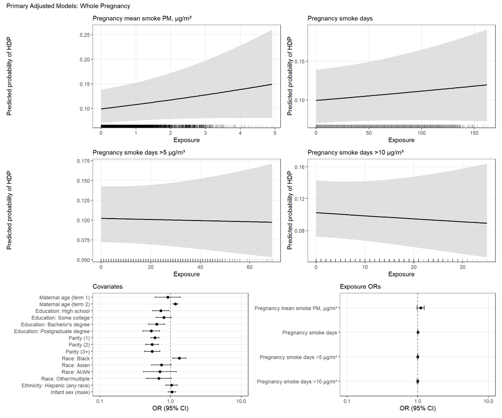

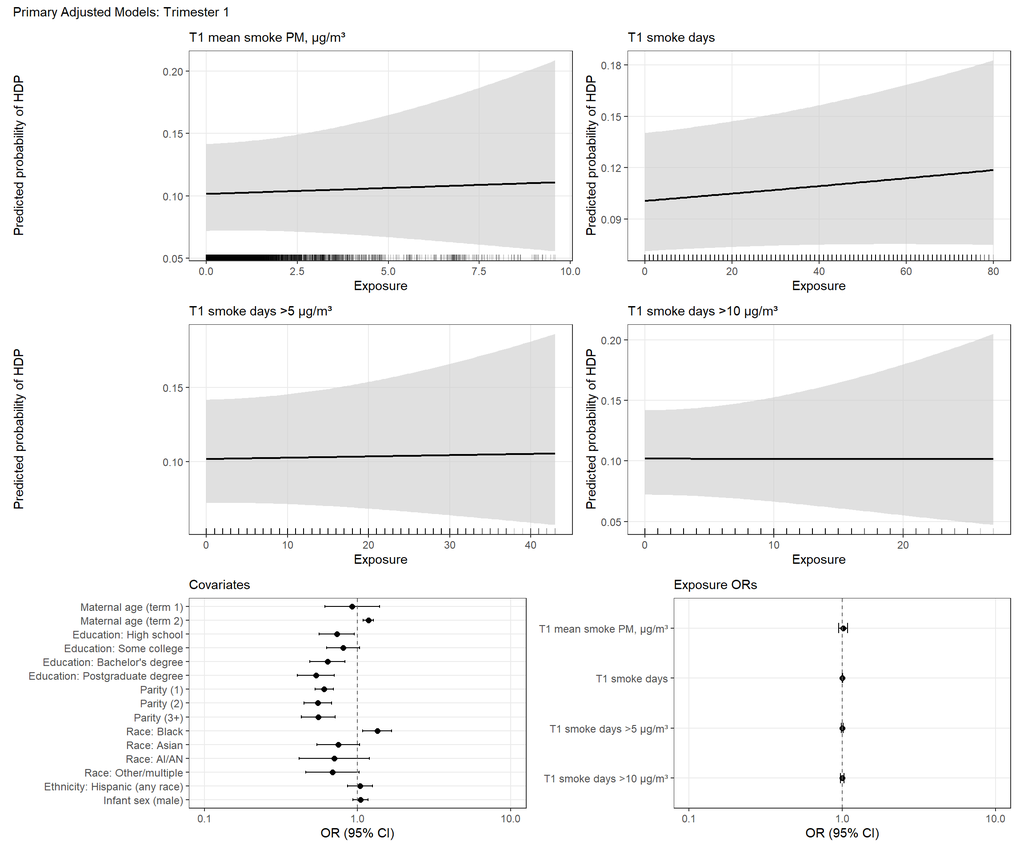

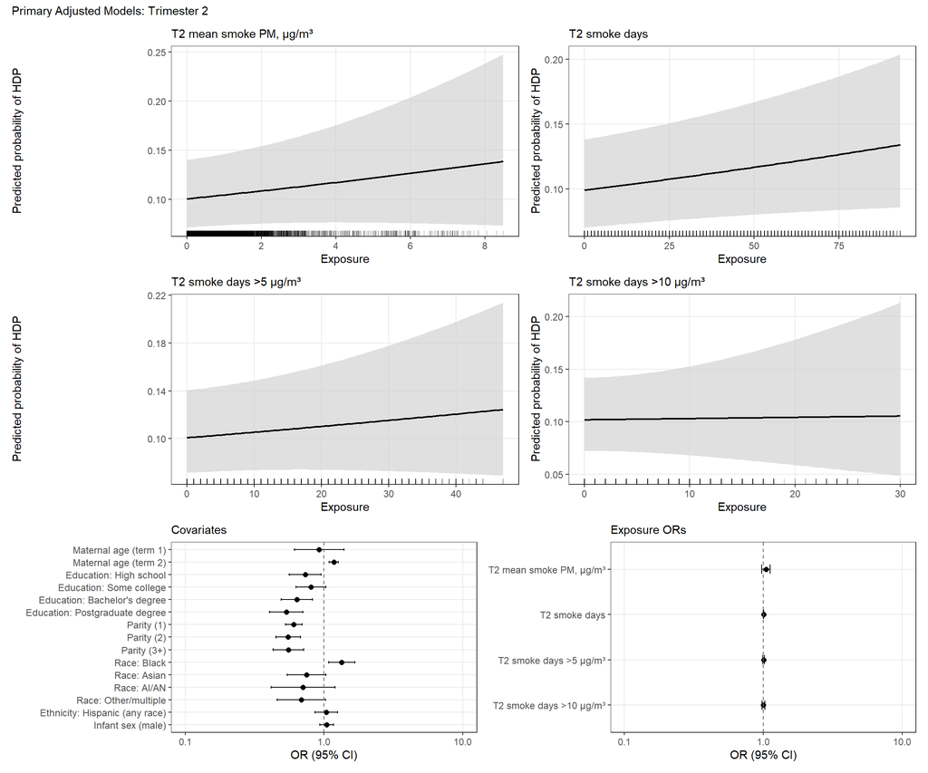

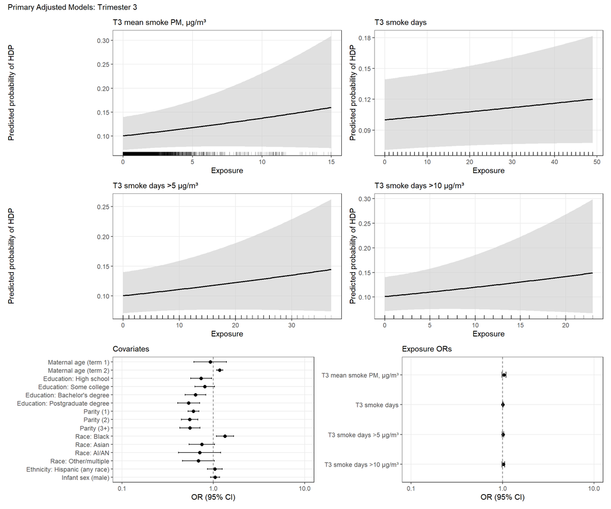

## 1.3 Fully Adjusted

From AP: “Extended models will be additionally adjusted for covariates selected based on availability of harmonized variables across cohorts, including household size-adjusted income (or neighborhood deprivation index), maternal pre-pregnancy BMI, history of chronic hypertension, history of pre-eclampsia, pre-pregnancy diabetes, prenatal smoking.”

- Model: Same parameters as primary adjusted model for exposure, outcome, cohort random intercept, handling missing data, and model optimization.
- Covariates: Maternal age (splined), secular trend (year splines), census macro region, tobacco use, alcohol consumption, tract-level poverty, pre-pregnancy BMI, birthing parent educational attainment, parity, race/ethnicity, infant sex

Extended Adjusted Model: preg_smoke_days

| Term | OR | 95% CI Low | 95% CI High | P-value |
| --- | --- | --- | --- | --- |
| Intercept | 0.084 | 0.047 | 0.150 | 0.0000 |
| preg_smoke_days (exposure) | 0.994 | 0.990 | 0.998 | 0.0015 |
| Maternal age (term 1) | 0.850 | 0.561 | 1.288 | 0.4442 |
| Maternal age (term 2) | 1.143 | 1.057 | 1.237 | 0.0009 |
| Year (term 1) | 0.784 | 0.520 | 1.181 | 0.2445 |
| Year (term 2) | 0.764 | 0.487 | 1.198 | 0.2406 |
| Year (term 3) | 1.537 | 0.992 | 2.380 | 0.0543 |
| Smoking | 1.130 | 0.899 | 1.420 | 0.2933 |
| Alcohol consumption | 0.952 | 0.805 | 1.126 | 0.5657 |
| Spring conception | 1.189 | 1.000 | 1.415 | 0.0505 |
| Summer conception | 0.982 | 0.834 | 1.156 | 0.8228 |
| Winter conception | 1.168 | 0.982 | 1.389 | 0.0795 |
| Midwest | 1.116 | 0.945 | 1.319 | 0.1965 |
| South | 1.155 | 0.970 | 1.375 | 0.1066 |
| West | 1.071 | 0.909 | 1.264 | 0.4121 |
| Tract-level poverty | 0.997 | 0.993 | 1.002 | 0.3172 |
| BMI: Normal weight | 0.919 | 0.594 | 1.422 | 0.7055 |
| BMI: Overweight | 1.385 | 0.900 | 2.132 | 0.1389 |
| BMI: Obese | 2.054 | 1.338 | 3.152 | 0.0010 |
| Education: High school | 0.737 | 0.565 | 0.960 | 0.0236 |
| Education: Some college | 0.824 | 0.642 | 1.057 | 0.1271 |
| Education: Bachelor’s degree | 0.723 | 0.554 | 0.942 | 0.0165 |
| Education: Postgraduate degree | 0.639 | 0.483 | 0.846 | 0.0017 |
| Parity (1) | 0.597 | 0.520 | 0.685 | 0.0000 |
| Parity (2) | 0.547 | 0.445 | 0.673 | 0.0000 |
| Parity (3+) | 0.532 | 0.412 | 0.687 | 0.0000 |
| Race: Black | 1.231 | 0.988 | 1.533 | 0.0641 |
| Race: Asian | 0.790 | 0.573 | 1.090 | 0.1512 |
| Race: AI/AN | 0.648 | 0.379 | 1.109 | 0.1134 |
| Race: Other/multiple | 0.667 | 0.446 | 0.998 | 0.0491 |
| Ethnicity: Hispanic (any race) | 0.927 | 0.766 | 1.121 | 0.4320 |
| Infant sex (male) | 1.049 | 0.936 | 1.176 | 0.4117 |

Extended Adjusted Model: T1_smoke_days

| Term | OR | 95% CI Low | 95% CI High | P-value |
| --- | --- | --- | --- | --- |
| Intercept | 0.076 | 0.043 | 0.136 | 0.0000 |
| T1_smoke_days (exposure) | 1.001 | 0.995 | 1.006 | 0.8330 |
| Maternal age (term 1) | 0.849 | 0.561 | 1.286 | 0.4393 |
| Maternal age (term 2) | 1.147 | 1.060 | 1.241 | 0.0006 |
| Year (term 1) | 1.032 | 0.704 | 1.513 | 0.8720 |
| Year (term 2) | 0.854 | 0.550 | 1.327 | 0.4827 |
| Year (term 3) | 1.076 | 0.727 | 1.593 | 0.7132 |
| Smoking | 1.136 | 0.904 | 1.427 | 0.2734 |
| Alcohol consumption | 0.953 | 0.806 | 1.128 | 0.5774 |
| Spring conception | 1.072 | 0.903 | 1.271 | 0.4279 |
| Summer conception | 0.950 | 0.785 | 1.149 | 0.5946 |
| Winter conception | 1.057 | 0.899 | 1.242 | 0.5053 |
| Midwest | 1.111 | 0.940 | 1.313 | 0.2176 |
| South | 1.153 | 0.969 | 1.374 | 0.1093 |
| West | 1.073 | 0.910 | 1.265 | 0.4030 |
| Tract-level poverty | 0.997 | 0.992 | 1.002 | 0.2954 |
| BMI: Normal weight | 0.920 | 0.595 | 1.422 | 0.7070 |
| BMI: Overweight | 1.384 | 0.899 | 2.130 | 0.1396 |
| BMI: Obese | 2.059 | 1.342 | 3.159 | 0.0010 |
| Education: High school | 0.735 | 0.565 | 0.958 | 0.0227 |
| Education: Some college | 0.825 | 0.643 | 1.058 | 0.1291 |
| Education: Bachelor’s degree | 0.720 | 0.552 | 0.939 | 0.0154 |
| Education: Postgraduate degree | 0.638 | 0.482 | 0.844 | 0.0017 |
| Parity (1) | 0.591 | 0.515 | 0.678 | 0.0000 |
| Parity (2) | 0.543 | 0.442 | 0.668 | 0.0000 |
| Parity (3+) | 0.526 | 0.407 | 0.679 | 0.0000 |
| Race: Black | 1.231 | 0.989 | 1.534 | 0.0633 |
| Race: Asian | 0.801 | 0.581 | 1.105 | 0.1768 |
| Race: AI/AN | 0.657 | 0.385 | 1.123 | 0.1248 |
| Race: Other/multiple | 0.674 | 0.450 | 1.009 | 0.0554 |
| Ethnicity: Hispanic (any race) | 0.942 | 0.778 | 1.139 | 0.5356 |
| Infant sex (male) | 1.047 | 0.934 | 1.173 | 0.4340 |

Extended Adjusted Model: T2_smoke_days

| Term | OR | 95% CI Low | 95% CI High | P-value |
| --- | --- | --- | --- | --- |
| Intercept | 0.076 | 0.043 | 0.136 | 0.0000 |
| T2_smoke_days (exposure) | 0.998 | 0.993 | 1.003 | 0.5234 |
| Maternal age (term 1) | 0.850 | 0.561 | 1.287 | 0.4422 |
| Maternal age (term 2) | 1.146 | 1.060 | 1.240 | 0.0007 |
| Year (term 1) | 0.992 | 0.674 | 1.460 | 0.9667 |
| Year (term 2) | 0.843 | 0.542 | 1.312 | 0.4491 |
| Year (term 3) | 1.131 | 0.759 | 1.684 | 0.5454 |
| Smoking | 1.135 | 0.903 | 1.425 | 0.2775 |
| Alcohol consumption | 0.952 | 0.805 | 1.127 | 0.5701 |
| Spring conception | 1.113 | 0.920 | 1.348 | 0.2701 |
| Summer conception | 0.959 | 0.815 | 1.129 | 0.6163 |
| Winter conception | 1.080 | 0.906 | 1.288 | 0.3918 |
| Midwest | 1.111 | 0.940 | 1.313 | 0.2154 |
| South | 1.153 | 0.968 | 1.373 | 0.1094 |
| West | 1.073 | 0.910 | 1.265 | 0.4040 |
| Tract-level poverty | 0.997 | 0.993 | 1.002 | 0.2986 |
| BMI: Normal weight | 0.919 | 0.594 | 1.421 | 0.7041 |
| BMI: Overweight | 1.383 | 0.899 | 2.128 | 0.1406 |
| BMI: Obese | 2.057 | 1.340 | 3.156 | 0.0010 |
| Education: High school | 0.736 | 0.565 | 0.959 | 0.0232 |
| Education: Some college | 0.825 | 0.644 | 1.059 | 0.1308 |
| Education: Bachelor’s degree | 0.721 | 0.553 | 0.940 | 0.0157 |
| Education: Postgraduate degree | 0.638 | 0.482 | 0.845 | 0.0017 |
| Parity (1) | 0.591 | 0.515 | 0.678 | 0.0000 |
| Parity (2) | 0.544 | 0.442 | 0.668 | 0.0000 |
| Parity (3+) | 0.527 | 0.408 | 0.680 | 0.0000 |
| Race: Black | 1.232 | 0.989 | 1.534 | 0.0629 |
| Race: Asian | 0.800 | 0.580 | 1.103 | 0.1727 |
| Race: AI/AN | 0.657 | 0.384 | 1.122 | 0.1239 |
| Race: Other/multiple | 0.673 | 0.450 | 1.007 | 0.0544 |
| Ethnicity: Hispanic (any race) | 0.940 | 0.777 | 1.137 | 0.5218 |
| Infant sex (male) | 1.047 | 0.934 | 1.174 | 0.4286 |

Extended Adjusted Model: T3_smoke_days

| Term | OR | 95% CI Low | 95% CI High | P-value |
| --- | --- | --- | --- | --- |
| Intercept | 0.077 | 0.043 | 0.137 | 0.0000 |
| T3_smoke_days (exposure) | 0.999 | 0.991 | 1.007 | 0.8068 |
| Maternal age (term 1) | 0.849 | 0.561 | 1.285 | 0.4391 |
| Maternal age (term 2) | 1.147 | 1.060 | 1.241 | 0.0006 |
| Year (term 1) | 1.017 | 0.696 | 1.484 | 0.9321 |
| Year (term 2) | 0.848 | 0.545 | 1.319 | 0.4647 |
| Year (term 3) | 1.098 | 0.745 | 1.617 | 0.6366 |
| Smoking | 1.136 | 0.904 | 1.427 | 0.2735 |
| Alcohol consumption | 0.953 | 0.806 | 1.128 | 0.5781 |
| Spring conception | 1.071 | 0.904 | 1.269 | 0.4259 |
| Summer conception | 0.953 | 0.803 | 1.132 | 0.5841 |
| Winter conception | 1.063 | 0.897 | 1.259 | 0.4834 |
| Midwest | 1.111 | 0.940 | 1.313 | 0.2157 |
| South | 1.154 | 0.969 | 1.374 | 0.1089 |
| West | 1.073 | 0.910 | 1.265 | 0.4030 |
| Tract-level poverty | 0.997 | 0.992 | 1.002 | 0.2969 |
| BMI: Normal weight | 0.920 | 0.595 | 1.423 | 0.7079 |
| BMI: Overweight | 1.384 | 0.899 | 2.131 | 0.1393 |
| BMI: Obese | 2.059 | 1.342 | 3.159 | 0.0010 |
| Education: High school | 0.735 | 0.564 | 0.958 | 0.0226 |
| Education: Some college | 0.824 | 0.643 | 1.057 | 0.1282 |
| Education: Bachelor’s degree | 0.720 | 0.552 | 0.939 | 0.0152 |
| Education: Postgraduate degree | 0.638 | 0.482 | 0.844 | 0.0017 |
| Parity (1) | 0.591 | 0.515 | 0.678 | 0.0000 |
| Parity (2) | 0.544 | 0.442 | 0.668 | 0.0000 |
| Parity (3+) | 0.526 | 0.407 | 0.679 | 0.0000 |
| Race: Black | 1.231 | 0.989 | 1.534 | 0.0633 |
| Race: Asian | 0.801 | 0.581 | 1.104 | 0.1754 |
| Race: AI/AN | 0.657 | 0.384 | 1.123 | 0.1242 |
| Race: Other/multiple | 0.674 | 0.450 | 1.008 | 0.0550 |
| Ethnicity: Hispanic (any race) | 0.941 | 0.778 | 1.138 | 0.5283 |
| Infant sex (male) | 1.047 | 0.934 | 1.174 | 0.4319 |

Extended Adjusted Model: preg_smoke_days_over5

| Term | OR | 95% CI Low | 95% CI High | P-value |
| --- | --- | --- | --- | --- |
| Intercept | 0.080 | 0.045 | 0.142 | 0.0000 |
| preg_smoke_days_over5 (exposure) | 0.989 | 0.980 | 0.998 | 0.0180 |
| Maternal age (term 1) | 0.850 | 0.561 | 1.287 | 0.4416 |
| Maternal age (term 2) | 1.147 | 1.060 | 1.241 | 0.0007 |
| Year (term 1) | 0.927 | 0.631 | 1.360 | 0.6965 |
| Year (term 2) | 0.828 | 0.532 | 1.289 | 0.4040 |
| Year (term 3) | 1.232 | 0.832 | 1.826 | 0.2980 |
| Smoking | 1.133 | 0.902 | 1.423 | 0.2841 |
| Alcohol consumption | 0.951 | 0.804 | 1.125 | 0.5567 |
| Spring conception | 1.125 | 0.952 | 1.328 | 0.1667 |
| Summer conception | 0.969 | 0.824 | 1.141 | 0.7084 |
| Winter conception | 1.100 | 0.932 | 1.297 | 0.2589 |
| Midwest | 1.112 | 0.941 | 1.314 | 0.2136 |
| South | 1.153 | 0.968 | 1.373 | 0.1108 |
| West | 1.070 | 0.907 | 1.262 | 0.4203 |
| Tract-level poverty | 0.997 | 0.993 | 1.002 | 0.2991 |
| BMI: Normal weight | 0.922 | 0.596 | 1.427 | 0.7164 |
| BMI: Overweight | 1.387 | 0.901 | 2.135 | 0.1374 |
| BMI: Obese | 2.061 | 1.343 | 3.162 | 0.0009 |
| Education: High school | 0.737 | 0.566 | 0.960 | 0.0237 |
| Education: Some college | 0.825 | 0.643 | 1.058 | 0.1288 |
| Education: Bachelor’s degree | 0.721 | 0.553 | 0.941 | 0.0159 |
| Education: Postgraduate degree | 0.638 | 0.482 | 0.845 | 0.0017 |
| Parity (1) | 0.594 | 0.518 | 0.682 | 0.0000 |
| Parity (2) | 0.545 | 0.444 | 0.670 | 0.0000 |
| Parity (3+) | 0.529 | 0.410 | 0.683 | 0.0000 |
| Race: Black | 1.241 | 0.996 | 1.546 | 0.0544 |
| Race: Asian | 0.797 | 0.578 | 1.100 | 0.1673 |
| Race: AI/AN | 0.657 | 0.384 | 1.122 | 0.1241 |
| Race: Other/multiple | 0.673 | 0.450 | 1.007 | 0.0542 |
| Ethnicity: Hispanic (any race) | 0.937 | 0.774 | 1.133 | 0.5006 |
| Infant sex (male) | 1.047 | 0.934 | 1.174 | 0.4274 |

Extended Adjusted Model: T1_smoke_days_over5

| Term | OR | 95% CI Low | 95% CI High | P-value |
| --- | --- | --- | --- | --- |
| Intercept | 0.076 | 0.043 | 0.136 | 0.0000 |
| T1_smoke_days_over5 (exposure) | 0.998 | 0.984 | 1.013 | 0.7983 |
| Maternal age (term 1) | 0.850 | 0.561 | 1.287 | 0.4423 |
| Maternal age (term 2) | 1.147 | 1.060 | 1.241 | 0.0006 |
| Year (term 1) | 1.019 | 0.699 | 1.484 | 0.9233 |
| Year (term 2) | 0.851 | 0.548 | 1.322 | 0.4735 |
| Year (term 3) | 1.094 | 0.746 | 1.605 | 0.6445 |
| Smoking | 1.135 | 0.903 | 1.425 | 0.2766 |
| Alcohol consumption | 0.953 | 0.805 | 1.127 | 0.5734 |
| Spring conception | 1.082 | 0.917 | 1.278 | 0.3500 |
| Summer conception | 0.968 | 0.812 | 1.154 | 0.7173 |
| Winter conception | 1.055 | 0.897 | 1.240 | 0.5165 |
| Midwest | 1.111 | 0.940 | 1.313 | 0.2161 |
| South | 1.154 | 0.969 | 1.374 | 0.1090 |
| West | 1.073 | 0.910 | 1.265 | 0.4048 |
| Tract-level poverty | 0.997 | 0.992 | 1.002 | 0.2968 |
| BMI: Normal weight | 0.920 | 0.595 | 1.423 | 0.7083 |
| BMI: Overweight | 1.385 | 0.900 | 2.132 | 0.1389 |
| BMI: Obese | 2.059 | 1.342 | 3.159 | 0.0009 |
| Education: High school | 0.736 | 0.565 | 0.958 | 0.0229 |
| Education: Some college | 0.825 | 0.643 | 1.058 | 0.1291 |
| Education: Bachelor’s degree | 0.720 | 0.552 | 0.939 | 0.0154 |
| Education: Postgraduate degree | 0.638 | 0.482 | 0.844 | 0.0017 |
| Parity (1) | 0.591 | 0.515 | 0.678 | 0.0000 |
| Parity (2) | 0.544 | 0.442 | 0.668 | 0.0000 |
| Parity (3+) | 0.526 | 0.407 | 0.679 | 0.0000 |
| Race: Black | 1.231 | 0.989 | 1.534 | 0.0631 |
| Race: Asian | 0.800 | 0.580 | 1.104 | 0.1747 |
| Race: AI/AN | 0.657 | 0.385 | 1.123 | 0.1248 |
| Race: Other/multiple | 0.674 | 0.450 | 1.008 | 0.0547 |
| Ethnicity: Hispanic (any race) | 0.941 | 0.778 | 1.138 | 0.5295 |
| Infant sex (male) | 1.047 | 0.934 | 1.174 | 0.4292 |

Extended Adjusted Model: T2_smoke_days_over5

| Term | OR | 95% CI Low | 95% CI High | P-value |
| --- | --- | --- | --- | --- |
| Intercept | 0.076 | 0.043 | 0.136 | 0.0000 |
| T2_smoke_days_over5 (exposure) | 0.994 | 0.980 | 1.007 | 0.3554 |
| Maternal age (term 1) | 0.849 | 0.561 | 1.286 | 0.4404 |
| Maternal age (term 2) | 1.147 | 1.060 | 1.241 | 0.0007 |
| Year (term 1) | 0.998 | 0.684 | 1.457 | 0.9926 |
| Year (term 2) | 0.846 | 0.544 | 1.314 | 0.4567 |
| Year (term 3) | 1.121 | 0.763 | 1.648 | 0.5604 |
| Smoking | 1.136 | 0.904 | 1.427 | 0.2733 |
| Alcohol consumption | 0.952 | 0.805 | 1.126 | 0.5671 |
| Spring conception | 1.114 | 0.934 | 1.330 | 0.2310 |
| Summer conception | 0.960 | 0.816 | 1.130 | 0.6236 |
| Winter conception | 1.081 | 0.913 | 1.279 | 0.3684 |
| Midwest | 1.110 | 0.940 | 1.312 | 0.2186 |
| South | 1.152 | 0.968 | 1.372 | 0.1116 |
| West | 1.072 | 0.909 | 1.264 | 0.4070 |
| Tract-level poverty | 0.997 | 0.992 | 1.002 | 0.2952 |
| BMI: Normal weight | 0.920 | 0.595 | 1.422 | 0.7070 |
| BMI: Overweight | 1.383 | 0.899 | 2.129 | 0.1405 |
| BMI: Obese | 2.057 | 1.341 | 3.157 | 0.0010 |
| Education: High school | 0.736 | 0.565 | 0.959 | 0.0232 |
| Education: Some college | 0.825 | 0.643 | 1.058 | 0.1299 |
| Education: Bachelor’s degree | 0.721 | 0.553 | 0.940 | 0.0157 |
| Education: Postgraduate degree | 0.638 | 0.482 | 0.845 | 0.0017 |
| Parity (1) | 0.591 | 0.515 | 0.678 | 0.0000 |
| Parity (2) | 0.544 | 0.442 | 0.668 | 0.0000 |
| Parity (3+) | 0.527 | 0.408 | 0.680 | 0.0000 |
| Race: Black | 1.235 | 0.991 | 1.538 | 0.0599 |
| Race: Asian | 0.800 | 0.580 | 1.104 | 0.1744 |
| Race: AI/AN | 0.658 | 0.385 | 1.124 | 0.1256 |
| Race: Other/multiple | 0.674 | 0.450 | 1.008 | 0.0547 |
| Ethnicity: Hispanic (any race) | 0.941 | 0.778 | 1.138 | 0.5285 |
| Infant sex (male) | 1.047 | 0.934 | 1.174 | 0.4305 |

Extended Adjusted Model: T3_smoke_days_over5

| Term | OR | 95% CI Low | 95% CI High | P-value |
| --- | --- | --- | --- | --- |
| Intercept | 0.076 | 0.042 | 0.135 | 0.0000 |
| T3_smoke_days_over5 (exposure) | 1.003 | 0.983 | 1.023 | 0.7862 |
| Maternal age (term 1) | 0.850 | 0.561 | 1.287 | 0.4422 |
| Maternal age (term 2) | 1.147 | 1.060 | 1.241 | 0.0006 |
| Year (term 1) | 1.029 | 0.706 | 1.499 | 0.8826 |
| Year (term 2) | 0.854 | 0.550 | 1.326 | 0.4818 |
| Year (term 3) | 1.081 | 0.737 | 1.585 | 0.6916 |
| Smoking | 1.135 | 0.904 | 1.426 | 0.2752 |
| Alcohol consumption | 0.953 | 0.806 | 1.128 | 0.5750 |
| Spring conception | 1.082 | 0.917 | 1.276 | 0.3499 |
| Summer conception | 0.965 | 0.817 | 1.140 | 0.6720 |
| Winter conception | 1.051 | 0.892 | 1.239 | 0.5516 |
| Midwest | 1.111 | 0.940 | 1.313 | 0.2177 |
| South | 1.153 | 0.968 | 1.373 | 0.1094 |
| West | 1.073 | 0.910 | 1.265 | 0.4044 |
| Tract-level poverty | 0.997 | 0.992 | 1.002 | 0.2958 |
| BMI: Normal weight | 0.920 | 0.595 | 1.422 | 0.7065 |
| BMI: Overweight | 1.384 | 0.899 | 2.130 | 0.1394 |
| BMI: Obese | 2.058 | 1.341 | 3.158 | 0.0010 |
| Education: High school | 0.736 | 0.565 | 0.958 | 0.0229 |
| Education: Some college | 0.825 | 0.643 | 1.058 | 0.1294 |
| Education: Bachelor’s degree | 0.720 | 0.552 | 0.939 | 0.0155 |
| Education: Postgraduate degree | 0.638 | 0.482 | 0.845 | 0.0017 |
| Parity (1) | 0.591 | 0.515 | 0.678 | 0.0000 |
| Parity (2) | 0.543 | 0.442 | 0.668 | 0.0000 |
| Parity (3+) | 0.526 | 0.407 | 0.679 | 0.0000 |
| Race: Black | 1.231 | 0.988 | 1.533 | 0.0639 |
| Race: Asian | 0.801 | 0.581 | 1.104 | 0.1756 |
| Race: AI/AN | 0.657 | 0.385 | 1.123 | 0.1248 |
| Race: Other/multiple | 0.674 | 0.450 | 1.008 | 0.0548 |
| Ethnicity: Hispanic (any race) | 0.941 | 0.778 | 1.139 | 0.5345 |
| Infant sex (male) | 1.047 | 0.934 | 1.174 | 0.4299 |

Extended Adjusted Model: preg_smoke_days_over10

| Term | OR | 95% CI Low | 95% CI High | P-value |
| --- | --- | --- | --- | --- |
| Intercept | 0.078 | 0.043 | 0.138 | 0.0000 |
| preg_smoke_days_over10 (exposure) | 0.984 | 0.966 | 1.001 | 0.0673 |
| Maternal age (term 1) | 0.850 | 0.562 | 1.288 | 0.4442 |
| Maternal age (term 2) | 1.147 | 1.060 | 1.241 | 0.0007 |
| Year (term 1) | 1.021 | 0.702 | 1.484 | 0.9133 |
| Year (term 2) | 0.826 | 0.531 | 1.283 | 0.3949 |
| Year (term 3) | 1.107 | 0.758 | 1.619 | 0.5983 |
| Smoking | 1.135 | 0.904 | 1.427 | 0.2752 |
| Alcohol consumption | 0.949 | 0.802 | 1.123 | 0.5446 |
| Spring conception | 1.101 | 0.935 | 1.298 | 0.2494 |
| Summer conception | 0.966 | 0.821 | 1.136 | 0.6743 |
| Winter conception | 1.078 | 0.916 | 1.269 | 0.3680 |
| Midwest | 1.109 | 0.939 | 1.311 | 0.2230 |
| South | 1.151 | 0.967 | 1.371 | 0.1142 |
| West | 1.071 | 0.909 | 1.263 | 0.4122 |
| Tract-level poverty | 0.997 | 0.993 | 1.002 | 0.3005 |
| BMI: Normal weight | 0.923 | 0.597 | 1.428 | 0.7192 |
| BMI: Overweight | 1.387 | 0.901 | 2.136 | 0.1370 |
| BMI: Obese | 2.063 | 1.344 | 3.165 | 0.0009 |
| Education: High school | 0.737 | 0.565 | 0.960 | 0.0234 |
| Education: Some college | 0.826 | 0.644 | 1.059 | 0.1315 |
| Education: Bachelor’s degree | 0.721 | 0.553 | 0.940 | 0.0158 |
| Education: Postgraduate degree | 0.639 | 0.483 | 0.845 | 0.0017 |
| Parity (1) | 0.593 | 0.517 | 0.680 | 0.0000 |
| Parity (2) | 0.545 | 0.443 | 0.670 | 0.0000 |
| Parity (3+) | 0.527 | 0.408 | 0.680 | 0.0000 |
| Race: Black | 1.237 | 0.993 | 1.541 | 0.0576 |
| Race: Asian | 0.799 | 0.579 | 1.101 | 0.1703 |
| Race: AI/AN | 0.661 | 0.387 | 1.130 | 0.1305 |
| Race: Other/multiple | 0.675 | 0.451 | 1.011 | 0.0563 |
| Ethnicity: Hispanic (any race) | 0.939 | 0.777 | 1.136 | 0.5186 |
| Infant sex (male) | 1.047 | 0.934 | 1.174 | 0.4320 |

Extended Adjusted Model: T1_smoke_days_over10

| Term | OR | 95% CI Low | 95% CI High | P-value |
| --- | --- | --- | --- | --- |
| Intercept | 0.076 | 0.043 | 0.136 | 0.0000 |
| T1_smoke_days_over10 (exposure) | 0.996 | 0.968 | 1.026 | 0.8113 |
| Maternal age (term 1) | 0.849 | 0.561 | 1.286 | 0.4407 |
| Maternal age (term 2) | 1.147 | 1.060 | 1.241 | 0.0006 |
| Year (term 1) | 1.024 | 0.704 | 1.489 | 0.9010 |
| Year (term 2) | 0.850 | 0.548 | 1.321 | 0.4705 |
| Year (term 3) | 1.088 | 0.744 | 1.591 | 0.6627 |
| Smoking | 1.135 | 0.904 | 1.426 | 0.2764 |
| Alcohol consumption | 0.953 | 0.805 | 1.127 | 0.5730 |
| Spring conception | 1.080 | 0.917 | 1.273 | 0.3556 |
| Summer conception | 0.965 | 0.815 | 1.143 | 0.6809 |
| Winter conception | 1.055 | 0.898 | 1.241 | 0.5129 |
| Midwest | 1.111 | 0.940 | 1.313 | 0.2168 |
| South | 1.153 | 0.969 | 1.374 | 0.1093 |
| West | 1.073 | 0.910 | 1.265 | 0.4043 |
| Tract-level poverty | 0.997 | 0.992 | 1.002 | 0.2968 |
| BMI: Normal weight | 0.920 | 0.595 | 1.423 | 0.7079 |
| BMI: Overweight | 1.385 | 0.900 | 2.131 | 0.1390 |
| BMI: Obese | 2.059 | 1.342 | 3.159 | 0.0010 |
| Education: High school | 0.736 | 0.565 | 0.958 | 0.0229 |
| Education: Some college | 0.825 | 0.643 | 1.058 | 0.1295 |
| Education: Bachelor’s degree | 0.720 | 0.552 | 0.939 | 0.0154 |
| Education: Postgraduate degree | 0.638 | 0.482 | 0.845 | 0.0017 |
| Parity (1) | 0.591 | 0.515 | 0.678 | 0.0000 |
| Parity (2) | 0.544 | 0.442 | 0.668 | 0.0000 |
| Parity (3+) | 0.526 | 0.407 | 0.679 | 0.0000 |
| Race: Black | 1.232 | 0.989 | 1.534 | 0.0630 |
| Race: Asian | 0.801 | 0.581 | 1.104 | 0.1752 |
| Race: AI/AN | 0.657 | 0.385 | 1.124 | 0.1250 |
| Race: Other/multiple | 0.674 | 0.450 | 1.008 | 0.0549 |
| Ethnicity: Hispanic (any race) | 0.941 | 0.778 | 1.138 | 0.5305 |
| Infant sex (male) | 1.047 | 0.934 | 1.174 | 0.4302 |

Extended Adjusted Model: T2_smoke_days_over10

| Term | OR | 95% CI Low | 95% CI High | P-value |
| --- | --- | --- | --- | --- |
| Intercept | 0.076 | 0.043 | 0.136 | 0.0000 |
| T2_smoke_days_over10 (exposure) | 0.985 | 0.959 | 1.012 | 0.2771 |
| Maternal age (term 1) | 0.850 | 0.561 | 1.287 | 0.4422 |
| Maternal age (term 2) | 1.147 | 1.060 | 1.240 | 0.0007 |
| Year (term 1) | 1.022 | 0.703 | 1.485 | 0.9109 |
| Year (term 2) | 0.842 | 0.542 | 1.308 | 0.4436 |
| Year (term 3) | 1.095 | 0.749 | 1.601 | 0.6394 |
| Smoking | 1.138 | 0.906 | 1.429 | 0.2677 |
| Alcohol consumption | 0.952 | 0.804 | 1.126 | 0.5640 |
| Spring conception | 1.107 | 0.935 | 1.311 | 0.2387 |
| Summer conception | 0.960 | 0.816 | 1.129 | 0.6219 |
| Winter conception | 1.074 | 0.911 | 1.266 | 0.3955 |
| Midwest | 1.110 | 0.939 | 1.311 | 0.2218 |
| South | 1.151 | 0.967 | 1.371 | 0.1138 |
| West | 1.072 | 0.909 | 1.264 | 0.4087 |
| Tract-level poverty | 0.997 | 0.992 | 1.002 | 0.2961 |
| BMI: Normal weight | 0.921 | 0.596 | 1.424 | 0.7109 |
| BMI: Overweight | 1.384 | 0.899 | 2.130 | 0.1399 |
| BMI: Obese | 2.059 | 1.342 | 3.160 | 0.0009 |
| Education: High school | 0.736 | 0.565 | 0.958 | 0.0228 |
| Education: Some college | 0.825 | 0.643 | 1.058 | 0.1288 |
| Education: Bachelor’s degree | 0.720 | 0.552 | 0.939 | 0.0154 |
| Education: Postgraduate degree | 0.638 | 0.482 | 0.844 | 0.0017 |
| Parity (1) | 0.591 | 0.515 | 0.678 | 0.0000 |
| Parity (2) | 0.544 | 0.442 | 0.668 | 0.0000 |
| Parity (3+) | 0.527 | 0.408 | 0.680 | 0.0000 |
| Race: Black | 1.234 | 0.990 | 1.537 | 0.0610 |
| Race: Asian | 0.801 | 0.581 | 1.104 | 0.1754 |
| Race: AI/AN | 0.659 | 0.386 | 1.127 | 0.1276 |
| Race: Other/multiple | 0.674 | 0.450 | 1.009 | 0.0550 |
| Ethnicity: Hispanic (any race) | 0.941 | 0.778 | 1.138 | 0.5279 |
| Infant sex (male) | 1.047 | 0.934 | 1.174 | 0.4319 |

Extended Adjusted Model: T3_smoke_days_over10

| Term | OR | 95% CI Low | 95% CI High | P-value |
| --- | --- | --- | --- | --- |
| Intercept | 0.076 | 0.043 | 0.136 | 0.0000 |
| T3_smoke_days_over10 (exposure) | 1.008 | 0.972 | 1.046 | 0.6619 |
| Maternal age (term 1) | 0.849 | 0.561 | 1.286 | 0.4402 |
| Maternal age (term 2) | 1.147 | 1.060 | 1.241 | 0.0007 |
| Year (term 1) | 1.024 | 0.704 | 1.490 | 0.9005 |
| Year (term 2) | 0.855 | 0.550 | 1.329 | 0.4866 |
| Year (term 3) | 1.085 | 0.742 | 1.587 | 0.6738 |
| Smoking | 1.135 | 0.904 | 1.425 | 0.2762 |
| Alcohol consumption | 0.953 | 0.806 | 1.128 | 0.5782 |
| Spring conception | 1.082 | 0.919 | 1.274 | 0.3467 |
| Summer conception | 0.964 | 0.818 | 1.136 | 0.6618 |
| Winter conception | 1.050 | 0.892 | 1.237 | 0.5541 |
| Midwest | 1.111 | 0.940 | 1.313 | 0.2179 |
| South | 1.153 | 0.968 | 1.373 | 0.1095 |
| West | 1.072 | 0.909 | 1.265 | 0.4058 |
| Tract-level poverty | 0.997 | 0.992 | 1.002 | 0.2956 |
| BMI: Normal weight | 0.919 | 0.595 | 1.422 | 0.7055 |
| BMI: Overweight | 1.384 | 0.899 | 2.130 | 0.1396 |
| BMI: Obese | 2.058 | 1.341 | 3.158 | 0.0010 |
| Education: High school | 0.736 | 0.565 | 0.959 | 0.0230 |
| Education: Some college | 0.825 | 0.643 | 1.058 | 0.1297 |
| Education: Bachelor’s degree | 0.720 | 0.552 | 0.940 | 0.0155 |
| Education: Postgraduate degree | 0.638 | 0.482 | 0.845 | 0.0017 |
| Parity (1) | 0.591 | 0.515 | 0.678 | 0.0000 |
| Parity (2) | 0.543 | 0.442 | 0.668 | 0.0000 |
| Parity (3+) | 0.526 | 0.407 | 0.679 | 0.0000 |
| Race: Black | 1.231 | 0.988 | 1.533 | 0.0642 |
| Race: Asian | 0.801 | 0.581 | 1.105 | 0.1762 |
| Race: AI/AN | 0.657 | 0.384 | 1.123 | 0.1244 |
| Race: Other/multiple | 0.673 | 0.450 | 1.008 | 0.0545 |
| Ethnicity: Hispanic (any race) | 0.941 | 0.778 | 1.138 | 0.5321 |
| Infant sex (male) | 1.047 | 0.934 | 1.174 | 0.4302 |

Extended Adjusted Model: preg_smokePM_mean

| Term | OR | 95% CI Low | 95% CI High | P-value |
| --- | --- | --- | --- | --- |
| Intercept | 0.077 | 0.043 | 0.138 | 0.0000 |
| preg_smokePM_mean (exposure) | 0.942 | 0.812 | 1.094 | 0.4354 |
| Maternal age (term 1) | 0.849 | 0.561 | 1.285 | 0.4388 |
| Maternal age (term 2) | 1.147 | 1.060 | 1.241 | 0.0006 |
| Year (term 1) | 0.993 | 0.678 | 1.455 | 0.9722 |
| Year (term 2) | 0.838 | 0.538 | 1.304 | 0.4337 |
| Year (term 3) | 1.134 | 0.765 | 1.681 | 0.5325 |
| Smoking | 1.135 | 0.903 | 1.425 | 0.2774 |
| Alcohol consumption | 0.952 | 0.804 | 1.126 | 0.5646 |
| Spring conception | 1.092 | 0.925 | 1.288 | 0.3003 |
| Summer conception | 0.962 | 0.818 | 1.132 | 0.6437 |
| Winter conception | 1.069 | 0.907 | 1.261 | 0.4250 |
| Midwest | 1.111 | 0.940 | 1.313 | 0.2153 |
| South | 1.153 | 0.969 | 1.374 | 0.1093 |
| West | 1.072 | 0.909 | 1.265 | 0.4058 |
| Tract-level poverty | 0.997 | 0.993 | 1.002 | 0.2987 |
| BMI: Normal weight | 0.921 | 0.595 | 1.424 | 0.7099 |
| BMI: Overweight | 1.385 | 0.900 | 2.132 | 0.1390 |
| BMI: Obese | 2.059 | 1.342 | 3.160 | 0.0009 |
| Education: High school | 0.736 | 0.565 | 0.959 | 0.0230 |
| Education: Some college | 0.825 | 0.643 | 1.058 | 0.1289 |
| Education: Bachelor’s degree | 0.720 | 0.552 | 0.939 | 0.0154 |
| Education: Postgraduate degree | 0.638 | 0.482 | 0.844 | 0.0017 |
| Parity (1) | 0.592 | 0.516 | 0.679 | 0.0000 |
| Parity (2) | 0.544 | 0.443 | 0.669 | 0.0000 |
| Parity (3+) | 0.527 | 0.408 | 0.680 | 0.0000 |
| Race: Black | 1.233 | 0.990 | 1.536 | 0.0616 |
| Race: Asian | 0.799 | 0.580 | 1.102 | 0.1721 |
| Race: AI/AN | 0.658 | 0.385 | 1.125 | 0.1259 |
| Race: Other/multiple | 0.673 | 0.450 | 1.008 | 0.0546 |
| Ethnicity: Hispanic (any race) | 0.939 | 0.776 | 1.136 | 0.5173 |
| Infant sex (male) | 1.047 | 0.934 | 1.174 | 0.4282 |

Extended Adjusted Model: T1_smokePM_mean

| Term | OR | 95% CI Low | 95% CI High | P-value |
| --- | --- | --- | --- | --- |
| Intercept | 0.076 | 0.043 | 0.136 | 0.0000 |
| T1_smokePM_mean (exposure) | 0.987 | 0.912 | 1.068 | 0.7445 |
| Maternal age (term 1) | 0.850 | 0.561 | 1.287 | 0.4422 |
| Maternal age (term 2) | 1.147 | 1.060 | 1.241 | 0.0007 |
| Year (term 1) | 1.018 | 0.699 | 1.483 | 0.9262 |
| Year (term 2) | 0.850 | 0.547 | 1.320 | 0.4683 |
| Year (term 3) | 1.096 | 0.748 | 1.607 | 0.6383 |
| Smoking | 1.135 | 0.903 | 1.425 | 0.2771 |
| Alcohol consumption | 0.953 | 0.805 | 1.127 | 0.5717 |
| Spring conception | 1.083 | 0.918 | 1.278 | 0.3437 |
| Summer conception | 0.970 | 0.815 | 1.155 | 0.7328 |
| Winter conception | 1.055 | 0.897 | 1.240 | 0.5176 |
| Midwest | 1.111 | 0.940 | 1.313 | 0.2161 |
| South | 1.154 | 0.969 | 1.374 | 0.1091 |
| West | 1.073 | 0.910 | 1.265 | 0.4050 |
| Tract-level poverty | 0.997 | 0.992 | 1.002 | 0.2972 |
| BMI: Normal weight | 0.920 | 0.595 | 1.423 | 0.7079 |
| BMI: Overweight | 1.385 | 0.900 | 2.131 | 0.1389 |
| BMI: Obese | 2.059 | 1.342 | 3.159 | 0.0010 |
| Education: High school | 0.736 | 0.565 | 0.958 | 0.0229 |
| Education: Some college | 0.825 | 0.643 | 1.058 | 0.1292 |
| Education: Bachelor’s degree | 0.720 | 0.552 | 0.939 | 0.0154 |
| Education: Postgraduate degree | 0.638 | 0.482 | 0.844 | 0.0017 |
| Parity (1) | 0.591 | 0.515 | 0.678 | 0.0000 |
| Parity (2) | 0.544 | 0.443 | 0.668 | 0.0000 |
| Parity (3+) | 0.526 | 0.408 | 0.679 | 0.0000 |
| Race: Black | 1.232 | 0.989 | 1.534 | 0.0631 |
| Race: Asian | 0.800 | 0.580 | 1.104 | 0.1744 |
| Race: AI/AN | 0.658 | 0.385 | 1.124 | 0.1252 |
| Race: Other/multiple | 0.673 | 0.450 | 1.008 | 0.0546 |
| Ethnicity: Hispanic (any race) | 0.941 | 0.778 | 1.138 | 0.5284 |
| Infant sex (male) | 1.047 | 0.934 | 1.174 | 0.4288 |

Extended Adjusted Model: T2_smokePM_mean

| Term | OR | 95% CI Low | 95% CI High | P-value |
| --- | --- | --- | --- | --- |
| Intercept | 0.076 | 0.043 | 0.136 | 0.0000 |
| T2_smokePM_mean (exposure) | 0.966 | 0.884 | 1.055 | 0.4384 |
| Maternal age (term 1) | 0.849 | 0.561 | 1.286 | 0.4406 |
| Maternal age (term 2) | 1.147 | 1.060 | 1.241 | 0.0007 |
| Year (term 1) | 1.003 | 0.687 | 1.464 | 0.9866 |
| Year (term 2) | 0.844 | 0.543 | 1.312 | 0.4503 |
| Year (term 3) | 1.116 | 0.759 | 1.642 | 0.5754 |
| Smoking | 1.136 | 0.904 | 1.426 | 0.2740 |
| Alcohol consumption | 0.952 | 0.805 | 1.126 | 0.5669 |
| Spring conception | 1.107 | 0.928 | 1.319 | 0.2579 |
| Summer conception | 0.960 | 0.816 | 1.129 | 0.6199 |
| Winter conception | 1.075 | 0.909 | 1.272 | 0.3967 |
| Midwest | 1.110 | 0.940 | 1.312 | 0.2192 |
| South | 1.153 | 0.968 | 1.373 | 0.1112 |
| West | 1.073 | 0.910 | 1.265 | 0.4049 |
| Tract-level poverty | 0.997 | 0.992 | 1.002 | 0.2962 |
| BMI: Normal weight | 0.920 | 0.595 | 1.422 | 0.7072 |
| BMI: Overweight | 1.383 | 0.899 | 2.129 | 0.1405 |
| BMI: Obese | 2.058 | 1.341 | 3.157 | 0.0010 |
| Education: High school | 0.736 | 0.565 | 0.958 | 0.0229 |
| Education: Some college | 0.825 | 0.643 | 1.058 | 0.1296 |
| Education: Bachelor’s degree | 0.721 | 0.552 | 0.940 | 0.0156 |
| Education: Postgraduate degree | 0.638 | 0.482 | 0.845 | 0.0017 |
| Parity (1) | 0.591 | 0.515 | 0.678 | 0.0000 |
| Parity (2) | 0.544 | 0.442 | 0.668 | 0.0000 |
| Parity (3+) | 0.527 | 0.408 | 0.680 | 0.0000 |
| Race: Black | 1.233 | 0.990 | 1.536 | 0.0619 |
| Race: Asian | 0.800 | 0.580 | 1.104 | 0.1741 |
| Race: AI/AN | 0.658 | 0.385 | 1.125 | 0.1258 |
| Race: Other/multiple | 0.673 | 0.450 | 1.008 | 0.0544 |
| Ethnicity: Hispanic (any race) | 0.940 | 0.777 | 1.137 | 0.5255 |
| Infant sex (male) | 1.047 | 0.934 | 1.174 | 0.4299 |

Extended Adjusted Model: T3_smokePM_mean

| Term | OR | 95% CI Low | 95% CI High | P-value |
| --- | --- | --- | --- | --- |
| Intercept | 0.076 | 0.043 | 0.136 | 0.0000 |
| T3_smokePM_mean (exposure) | 1.007 | 0.949 | 1.069 | 0.8114 |
| Maternal age (term 1) | 0.850 | 0.561 | 1.287 | 0.4422 |
| Maternal age (term 2) | 1.147 | 1.060 | 1.241 | 0.0007 |
| Year (term 1) | 1.027 | 0.705 | 1.496 | 0.8878 |
| Year (term 2) | 0.854 | 0.550 | 1.327 | 0.4831 |
| Year (term 3) | 1.082 | 0.738 | 1.586 | 0.6871 |
| Smoking | 1.135 | 0.904 | 1.426 | 0.2753 |
| Alcohol consumption | 0.953 | 0.806 | 1.128 | 0.5754 |
| Spring conception | 1.081 | 0.917 | 1.275 | 0.3533 |
| Summer conception | 0.964 | 0.816 | 1.138 | 0.6628 |
| Winter conception | 1.052 | 0.892 | 1.240 | 0.5479 |
| Midwest | 1.111 | 0.940 | 1.313 | 0.2178 |
| South | 1.153 | 0.968 | 1.373 | 0.1095 |
| West | 1.073 | 0.910 | 1.265 | 0.4050 |
| Tract-level poverty | 0.997 | 0.992 | 1.002 | 0.2956 |
| BMI: Normal weight | 0.920 | 0.595 | 1.422 | 0.7065 |
| BMI: Overweight | 1.384 | 0.899 | 2.130 | 0.1394 |
| BMI: Obese | 2.058 | 1.341 | 3.158 | 0.0010 |
| Education: High school | 0.736 | 0.565 | 0.959 | 0.0230 |
| Education: Some college | 0.825 | 0.643 | 1.058 | 0.1297 |
| Education: Bachelor’s degree | 0.720 | 0.552 | 0.939 | 0.0155 |
| Education: Postgraduate degree | 0.638 | 0.482 | 0.845 | 0.0017 |
| Parity (1) | 0.591 | 0.515 | 0.678 | 0.0000 |
| Parity (2) | 0.543 | 0.442 | 0.668 | 0.0000 |
| Parity (3+) | 0.526 | 0.407 | 0.679 | 0.0000 |
| Race: Black | 1.231 | 0.988 | 1.533 | 0.0637 |
| Race: Asian | 0.801 | 0.581 | 1.104 | 0.1757 |
| Race: AI/AN | 0.657 | 0.385 | 1.123 | 0.1247 |
| Race: Other/multiple | 0.674 | 0.450 | 1.008 | 0.0549 |
| Ethnicity: Hispanic (any race) | 0.941 | 0.778 | 1.139 | 0.5337 |
| Infant sex (male) | 1.047 | 0.934 | 1.174 | 0.4301 |

### 1.3.1 Plot

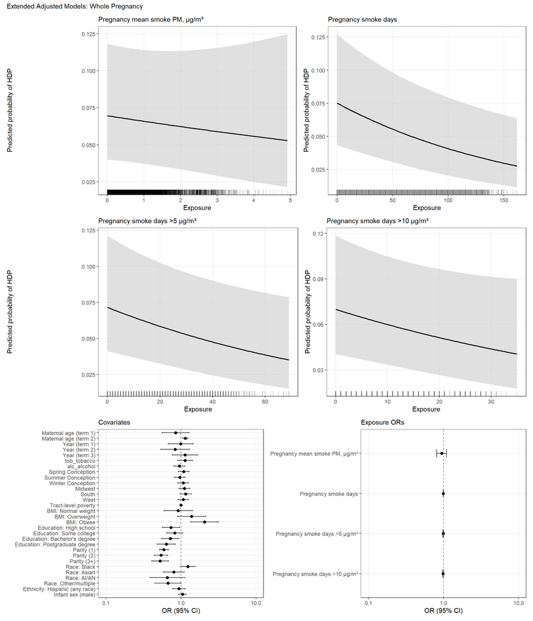

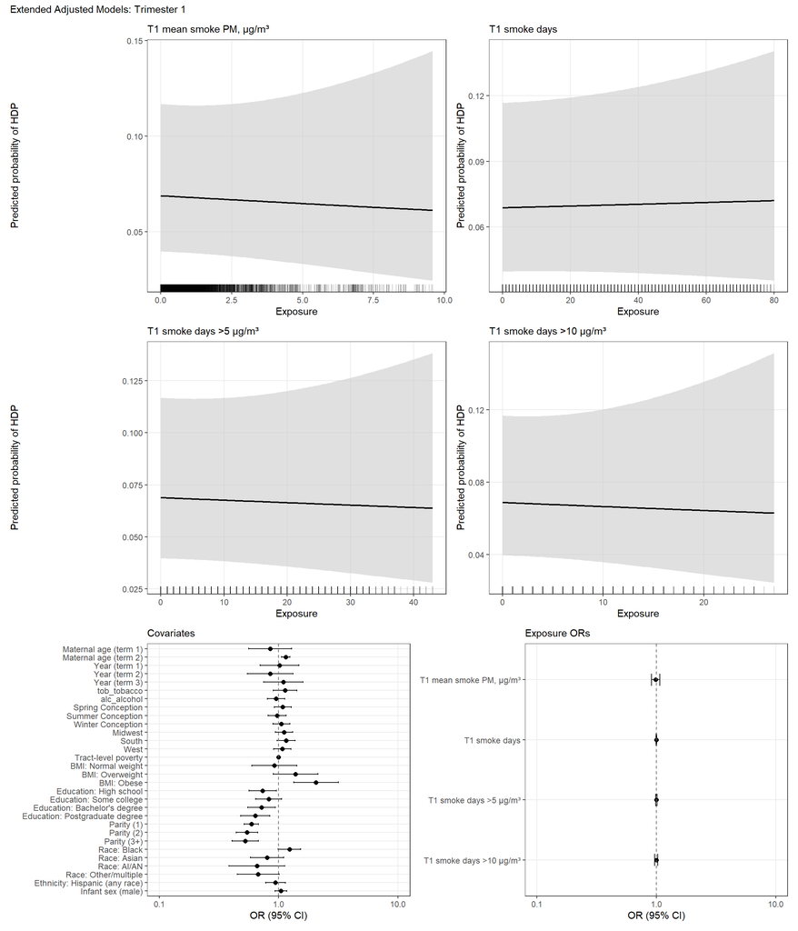

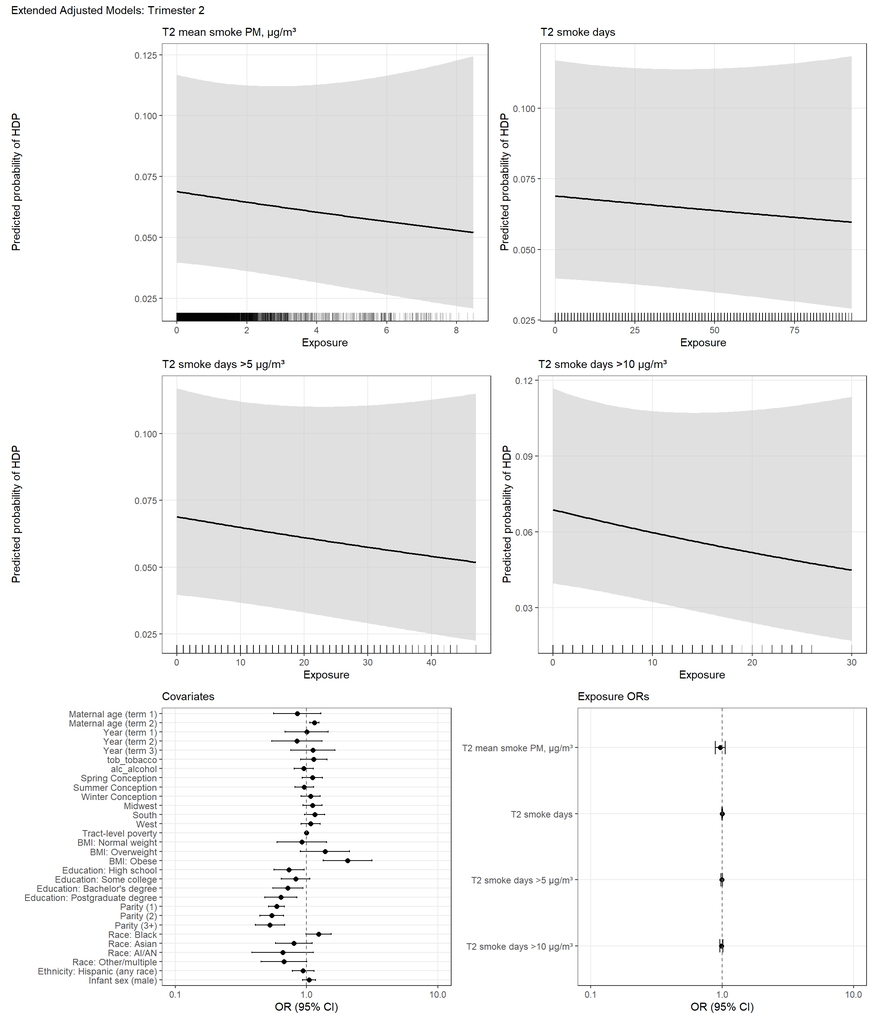

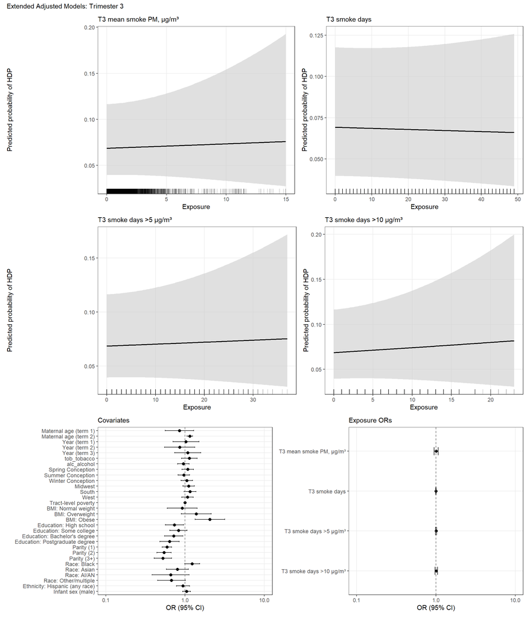

# 2 Effect Measure Modification

## 2.1 Mean PM X Infant Sex

- n male = 10801
- n female = 10232

Effect Measure Modification by Infant Sex: Mean Smoke PM

|  | Exposure | Stratum | OR | 95% CI Low | 95% CI High | P-value | P-heterogeneity |
| --- | --- | --- | --- | --- | --- | --- | --- |
| preg_smokePM_mean…1 | Pregnancy mean smoke PM, μg/m³ | Male | 0.912 | 0.739 | 1.126 | 0.3927 | 0.6287 |
| preg_smokePM_mean…2 | Pregnancy mean smoke PM, μg/m³ | Female | 0.981 | 0.797 | 1.208 | 0.8582 | 0.6287 |
| T1_smokePM_mean…3 | T1 mean smoke PM, μg/m³ | Male | 1.008 | 0.907 | 1.121 | 0.8818 | 0.6433 |
| T1_smokePM_mean…4 | T1 mean smoke PM, μg/m³ | Female | 0.971 | 0.864 | 1.092 | 0.6241 | 0.6433 |
| T2_smokePM_mean…5 | T2 mean smoke PM, μg/m³ | Male | 0.907 | 0.795 | 1.035 | 0.1486 | 0.1894 |
| T2_smokePM_mean…6 | T2 mean smoke PM, μg/m³ | Female | 1.022 | 0.908 | 1.150 | 0.7226 | 0.1894 |
| T3_smokePM_mean…7 | T3 mean smoke PM, μg/m³ | Male | 1.006 | 0.922 | 1.098 | 0.8874 | 0.9890 |
| T3_smokePM_mean…8 | T3 mean smoke PM, μg/m³ | Female | 1.005 | 0.926 | 1.092 | 0.8966 | 0.9890 |

### 2.1.1 Plot

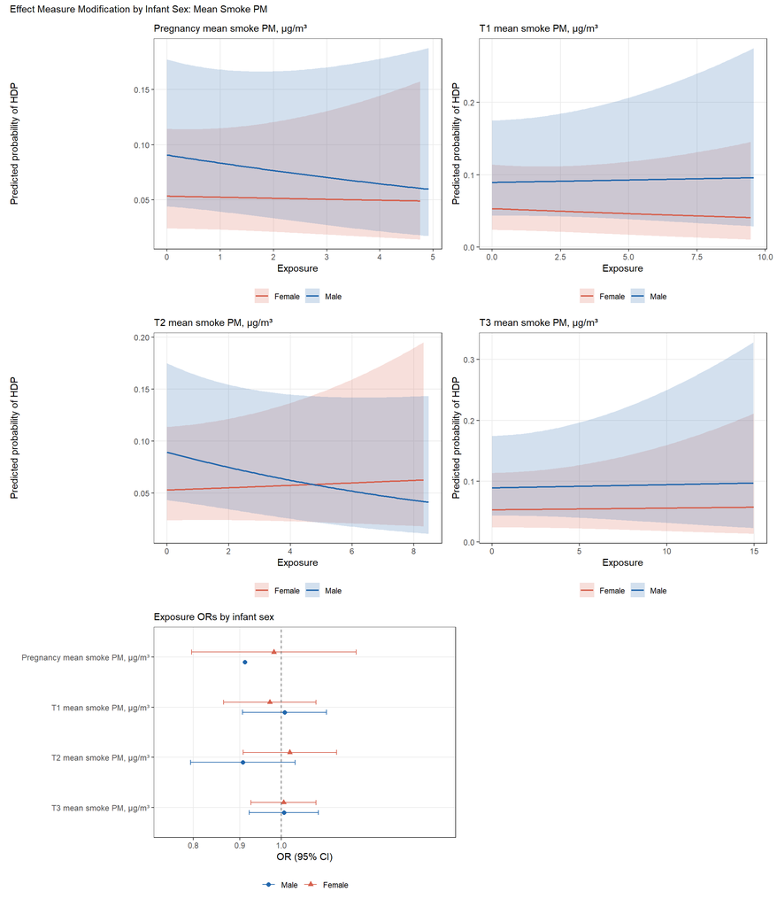

## 2.2 Mean PM X Census Region

- n Northeast = 8098
- n Midwest = 4524
- n South = 3357
- n West = 5055

Effect Measure Modification by Census Region: Mean Smoke PM

|  | Exposure | Stratum | OR | 95% CI Low | 95% CI High | P-value | P-heterogeneity |
| --- | --- | --- | --- | --- | --- | --- | --- |
| preg_smokePM_mean…1 | Pregnancy mean smoke PM, μg/m³ | Northeast | 0.852 | 0.640 | 1.135 | 0.2729 | 0.4211 |
| preg_smokePM_mean…2 | Pregnancy mean smoke PM, μg/m³ | Midwest | 0.865 | 0.662 | 1.131 | 0.2896 | 0.4211 |
| preg_smokePM_mean…3 | Pregnancy mean smoke PM, μg/m³ | South | 1.010 | 0.721 | 1.415 | 0.9528 | 0.4211 |
| preg_smokePM_mean…4 | Pregnancy mean smoke PM, μg/m³ | West | 1.156 | 0.858 | 1.559 | 0.3403 | 0.4211 |
| T1_smokePM_mean…5 | T1 mean smoke PM, μg/m³ | Northeast | 1.084 | 0.943 | 1.247 | 0.2554 | 0.2293 |
| T1_smokePM_mean…6 | T1 mean smoke PM, μg/m³ | Midwest | 0.883 | 0.756 | 1.031 | 0.1166 | 0.2293 |
| T1_smokePM_mean…7 | T1 mean smoke PM, μg/m³ | South | 0.977 | 0.812 | 1.175 | 0.8015 | 0.2293 |
| T1_smokePM_mean…8 | T1 mean smoke PM, μg/m³ | West | 1.060 | 0.902 | 1.245 | 0.4783 | 0.2293 |
| T2_smokePM_mean…9 | T2 mean smoke PM, μg/m³ | Northeast | 0.875 | 0.728 | 1.052 | 0.1556 | 0.1862 |
| T2_smokePM_mean…10 | T2 mean smoke PM, μg/m³ | Midwest | 0.911 | 0.769 | 1.079 | 0.2806 | 0.1862 |
| T2_smokePM_mean…11 | T2 mean smoke PM, μg/m³ | South | 0.990 | 0.812 | 1.209 | 0.9250 | 0.1862 |
| T2_smokePM_mean…12 | T2 mean smoke PM, μg/m³ | West | 1.120 | 0.953 | 1.315 | 0.1681 | 0.1862 |
| T3_smokePM_mean…13 | T3 mean smoke PM, μg/m³ | Northeast | 0.964 | 0.846 | 1.098 | 0.5783 | 0.4850 |
| T3_smokePM_mean…14 | T3 mean smoke PM, μg/m³ | Midwest | 1.068 | 0.972 | 1.174 | 0.1682 | 0.4850 |
| T3_smokePM_mean…15 | T3 mean smoke PM, μg/m³ | South | 0.986 | 0.857 | 1.134 | 0.8435 | 0.4850 |
| T3_smokePM_mean…16 | T3 mean smoke PM, μg/m³ | West | 0.963 | 0.840 | 1.104 | 0.5896 | 0.4850 |

### 2.2.1 Plot

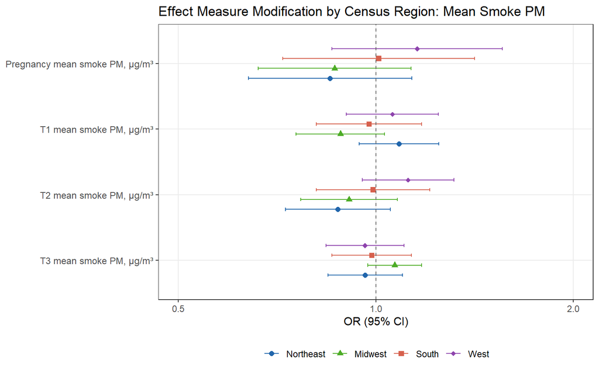